# Ejercicios resueltos

# Ejercicio 15

Cargamos las librerias

```r
pacman::p_load("ISLR2", "sandwich", "jtools", "huxtable")
```

Cargamos e inspeccionamos los datos

```r
data(Auto)
str(Auto)
```

```
## 'data.frame':    392 obs. of  9 variables:
##  $ mpg         : num  18 15 18 16 17 15 14 14 14 15 ...
##  $ cylinders   : int  8 8 8 8 8 8 8 8 8 8 ...
##  $ displacement: num  307 350 318 304 302 429 454 440 455 390 ...
##  $ horsepower  : int  130 165 150 150 140 198 220 215 225 190 ...
##  $ weight      : int  3504 3693 3436 3433 3449 4341 4354 4312 4425 3850 ...
##  $ acceleration: num  12 11.5 11 12 10.5 10 9 8.5 10 8.5 ...
##  $ year        : int  70 70 70 70 70 70 70 70 70 70 ...
##  $ origin      : int  1 1 1 1 1 1 1 1 1 1 ...
##  $ name        : Factor w/ 304 levels "amc ambassador brougham",..: 49 36 231 14 161 141 54 223 241 2 ...
##  - attr(*, "na.action")= 'omit' Named int [1:5] 33 127 331 337 355
##   ..- attr(*, "names")= chr [1:5] "33" "127" "331" "337" ...
```

```r
head(Auto)
```

| mpg | cylinders | displacement | horsepower | weight | acceleration | year | origin | name |
| --- | --- | --- | --- | --- | --- | --- | --- | --- |
| 18 | 8 | 307 | 130 | 3504 | 12 | 70 | 1 | chevrolet chevelle malibu |
| 15 | 8 | 350 | 165 | 3693 | 11.5 | 70 | 1 | buick skylark 320 |
| 18 | 8 | 318 | 150 | 3436 | 11 | 70 | 1 | plymouth satellite |
| 16 | 8 | 304 | 150 | 3433 | 12 | 70 | 1 | amc rebel sst |
| 17 | 8 | 302 | 140 | 3449 | 10.5 | 70 | 1 | ford torino |
| 15 | 8 | 429 | 198 | 4341 | 10 | 70 | 1 | ford galaxie 500 |

## a)

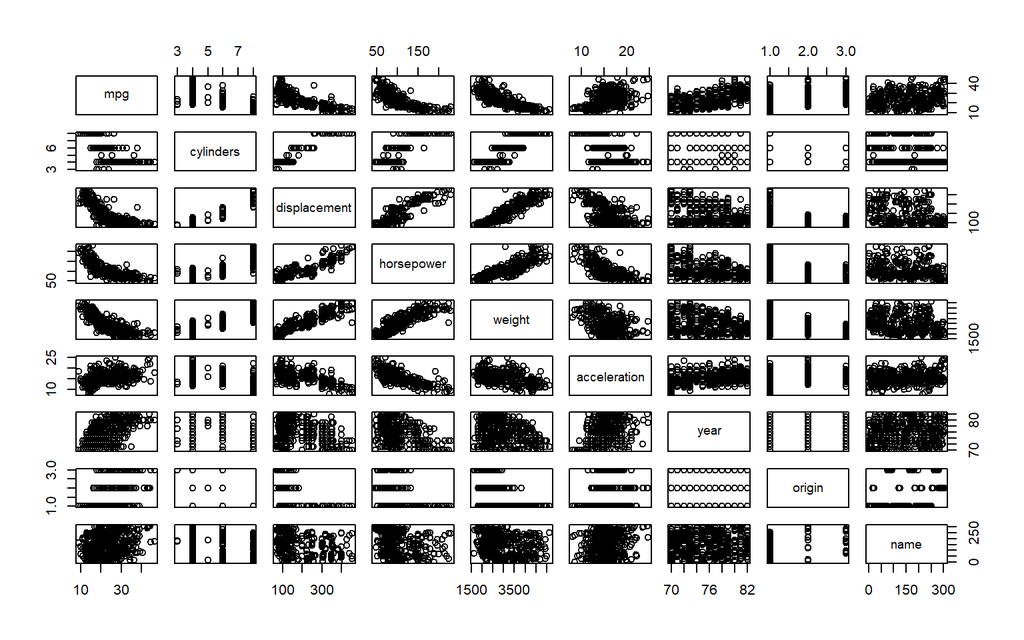

```r
plot(Auto)
```

## b)

Excluimos la última columa (9)

```r
cor(Auto[,-9])
```

```
##                     mpg  cylinders displacement horsepower     weight
## mpg           1.0000000 -0.7776175   -0.8051269 -0.7784268 -0.8322442
## cylinders    -0.7776175  1.0000000    0.9508233  0.8429834  0.8975273
## displacement -0.8051269  0.9508233    1.0000000  0.8972570  0.9329944
## horsepower   -0.7784268  0.8429834    0.8972570  1.0000000  0.8645377
## weight       -0.8322442  0.8975273    0.9329944  0.8645377  1.0000000
## acceleration  0.4233285 -0.5046834   -0.5438005 -0.6891955 -0.4168392
## year          0.5805410 -0.3456474   -0.3698552 -0.4163615 -0.3091199
## origin        0.5652088 -0.5689316   -0.6145351 -0.4551715 -0.5850054
##              acceleration       year     origin
## mpg             0.4233285  0.5805410  0.5652088
## cylinders      -0.5046834 -0.3456474 -0.5689316
## displacement   -0.5438005 -0.3698552 -0.6145351
## horsepower     -0.6891955 -0.4163615 -0.4551715
## weight         -0.4168392 -0.3091199 -0.5850054
## acceleration    1.0000000  0.2903161  0.2127458
## year            0.2903161  1.0000000  0.1815277
## origin          0.2127458  0.1815277  1.0000000
```

## c)

```r
modelo_15_01 <- lm(formula = mpg ~ . -name, data = Auto)
summary(modelo_15_01)
```

```
##
## Call:
## lm(formula = mpg ~ . - name, data = Auto)
##
## Residuals:
##     Min      1Q  Median      3Q     Max
## -9.5903 -2.1565 -0.1169  1.8690 13.0604
##
## Coefficients:
##                Estimate Std. Error t value Pr(>|t|)
## (Intercept)  -17.218435   4.644294  -3.707  0.00024 ***
## cylinders     -0.493376   0.323282  -1.526  0.12780
## displacement   0.019896   0.007515   2.647  0.00844 **
## horsepower    -0.016951   0.013787  -1.230  0.21963
## weight        -0.006474   0.000652  -9.929  < 2e-16 ***
## acceleration   0.080576   0.098845   0.815  0.41548
## year           0.750773   0.050973  14.729  < 2e-16 ***
## origin         1.426141   0.278136   5.127 4.67e-07 ***
## ---
## Signif. codes:  0 '***' 0.001 '**' 0.01 '*' 0.05 '.' 0.1 ' ' 1
##
## Residual standard error: 3.328 on 384 degrees of freedom
## Multiple R-squared:  0.8215, Adjusted R-squared:  0.8182
## F-statistic: 252.4 on 7 and 384 DF,  p-value: < 2.2e-16
```

### i)

Si, ya que ninguno de los coeficientes estimados es igual a cero

### ii)

Existe una relación estadísticamente significativa entre todos los regrtesores excepto *cylinders*, *horsepower* y *acceleration*

# Ejercicio 16

Cargamos e inspeccionamos los datos

```r
data("Carseats")
str(Carseats)
```

```
## 'data.frame':    400 obs. of  11 variables:
##  $ Sales      : num  9.5 11.22 10.06 7.4 4.15 ...
##  $ CompPrice  : num  138 111 113 117 141 124 115 136 132 132 ...
##  $ Income     : num  73 48 35 100 64 113 105 81 110 113 ...
##  $ Advertising: num  11 16 10 4 3 13 0 15 0 0 ...
##  $ Population : num  276 260 269 466 340 501 45 425 108 131 ...
##  $ Price      : num  120 83 80 97 128 72 108 120 124 124 ...
##  $ ShelveLoc  : Factor w/ 3 levels "Bad","Good","Medium": 1 2 3 3 1 1 3 2 3 3 ...
##  $ Age        : num  42 65 59 55 38 78 71 67 76 76 ...
##  $ Education  : num  17 10 12 14 13 16 15 10 10 17 ...
##  $ Urban      : Factor w/ 2 levels "No","Yes": 2 2 2 2 2 1 2 2 1 1 ...
##  $ US         : Factor w/ 2 levels "No","Yes": 2 2 2 2 1 2 1 2 1 2 ...
```

```r
head(Carseats)
```

| Sales | CompPrice | Income | Advertising | Population | Price | ShelveLoc | Age | Education | Urban | US |
| --- | --- | --- | --- | --- | --- | --- | --- | --- | --- | --- |
| 9.5 | 138 | 73 | 11 | 276 | 120 | Bad | 42 | 17 | Yes | Yes |
| 11.2 | 111 | 48 | 16 | 260 | 83 | Good | 65 | 10 | Yes | Yes |
| 10.1 | 113 | 35 | 10 | 269 | 80 | Medium | 59 | 12 | Yes | Yes |
| 7.4 | 117 | 100 | 4 | 466 | 97 | Medium | 55 | 14 | Yes | Yes |
| 4.15 | 141 | 64 | 3 | 340 | 128 | Bad | 38 | 13 | Yes | No |
| 10.8 | 124 | 113 | 13 | 501 | 72 | Bad | 78 | 16 | No | Yes |

## a)

```r
modelo_16_01 <- lm(formula = Sales ~ Price + Urban + US, data = Carseats)
summ(modelo_16_01)
```

| Observations | 400 |
| --- | --- |
| Dependent variable | Sales |
| Type | OLS linear regression |

| F(3,396) | 41.52 |
| --- | --- |
| R² | 0.24 |
| Adj. R² | 0.23 |

|  | Est. | S.E. | t val. | p |
| --- | --- | --- | --- | --- |
| (Intercept) | 13.04 | 0.65 | 20.04 | 0.00 |
| Price | -0.05 | 0.01 | -10.39 | 0.00 |
| UrbanYes | -0.02 | 0.27 | -0.08 | 0.94 |
| USYes | 1.20 | 0.26 | 4.63 | 0.00 |

Standard errors: OLS

## b)

Un incremento unitario del precio disminuye las ventas en 0.05 miles de dolares Si la tienda esta en una zona urbana, las ventas son menores Si la tienda está en USA las ventas son mayores

## c)

$\hat{Sales} =$ 13.04 -0.05$Price$ -0.02$Urban$ + 1.2$US$

## c)

Observando el p-valor de los coeficientes, podemos rechazar la hipótesis nula $\beta_j=0$ para *Price* y *US*

## e)

Eliminamos la variable *Urban* al no ser estadísticamente significativa de cero y reestimamos el modelo

```r
modelo_16_02 <- lm(formula = Sales ~ Price + US, data = Carseats)
summ(modelo_16_02)
```

| Observations | 400 |
| --- | --- |
| Dependent variable | Sales |
| Type | OLS linear regression |

| F(2,397) | 62.43 |
| --- | --- |
| R² | 0.24 |
| Adj. R² | 0.24 |

|  | Est. | S.E. | t val. | p |
| --- | --- | --- | --- | --- |
| (Intercept) | 13.03 | 0.63 | 20.65 | 0.00 |
| Price | -0.05 | 0.01 | -10.42 | 0.00 |
| USYes | 1.20 | 0.26 | 4.64 | 0.00 |

Standard errors: OLS

## f)

```r
export_summs(modelo_16_01, modelo_16_02, digits=3)
```

|  | Model 1 | Model 2 |
| --- | --- | --- |
| (Intercept) | 13.043 *** | 13.031 *** |
|  | (0.651) | (0.631) |
| Price | -0.054 *** | -0.054 *** |
|  | (0.005) | (0.005) |
| UrbanYes | -0.022 |  |
|  | (0.272) |  |
| USYes | 1.201 *** | 1.200 *** |
|  | (0.259) | (0.258) |
| N | 400 | 400 |
| R2 | 0.239 | 0.239 |
| *** p < 0.001; ** p < 0.01; * p < 0.05. |  |  |

Según el $R^2$ de ambos modelos, el ajuste es casi el mismo

## g)

```r
modelo_16_02 <- lm(formula = Sales ~ Price + US, data = Carseats)
summ(modelo_16_02, confint = TRUE)
```

| Observations | 400 |
| --- | --- |
| Dependent variable | Sales |
| Type | OLS linear regression |

| F(2,397) | 62.43 |
| --- | --- |
| R² | 0.24 |
| Adj. R² | 0.24 |

|  | Est. | 2.5% | 97.5% | t val. | p |
| --- | --- | --- | --- | --- | --- |
| (Intercept) | 13.03 | 11.79 | 14.27 | 20.65 | 0.00 |
| Price | -0.05 | -0.06 | -0.04 | -10.42 | 0.00 |
| USYes | 1.20 | 0.69 | 1.71 | 4.64 | 0.00 |

Standard errors: OLS

# Ejercicio 17

## a)

```r
set.seed ( 1 )
x1 <- runif (100)
x2 <- 0.5*x1 + rnorm (100) / 10
y <-- 2 + 2*x1 + 0.3*x2 + rnorm (100)
```

## b)

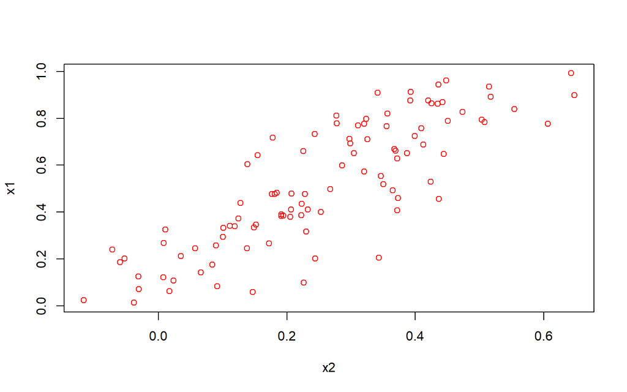

```r
plot(x2, x1, col="red")
```

Calculamos la correlación

```r
cor(x1, x2)
```

```
## [1] 0.8351212
```

Observamos que es relativamente alta, lo cual viene dado por como hemos construido $x_2$

## c)

```r
modelo_17_01 <- lm(y ~x1 + x2)
summ(modelo_17_01, digits = 3)
```

| Observations | 100 |
| --- | --- |
| Dependent variable | y |
| Type | OLS linear regression |

| F(2,97) | 12.802 |
| --- | --- |
| R² | 0.209 |
| Adj. R² | 0.193 |

|  | Est. | S.E. | t val. | p |
| --- | --- | --- | --- | --- |
| (Intercept) | -1.870 | 0.232 | -8.062 | 0.000 |
| x1 | 1.440 | 0.721 | 1.996 | 0.049 |
| x2 | 1.010 | 1.134 | 0.891 | 0.375 |

Standard errors: OLS

Los parámetros estimados no son los mismos que los verdaderos valores. No podemos rechazar la hipótesis nula $H_0: \beta_2=0$

## d)

```r
modelo_17_02 <- lm(y ~x1 )
summ(modelo_17_02, digits = 3)
```

| Observations | 100 |
| --- | --- |
| Dependent variable | y |
| Type | OLS linear regression |

| F(1,98) | 24.862 |
| --- | --- |
| R² | 0.202 |
| Adj. R² | 0.194 |

|  | Est. | S.E. | t val. | p |
| --- | --- | --- | --- | --- |
| (Intercept) | -1.888 | 0.231 | -8.180 | 0.000 |
| x1 | 1.976 | 0.396 | 4.986 | 0.000 |

Standard errors: OLS

Ahora el parámetro $\beta_1$ si coinicide con el dato verdadero. Si podemos rechazar la hipótesis nula $H_0: \beta_1=0$

## e)

```r
modelo_17_03 <- lm(y ~x2 )
summ(modelo_17_03, digits = 3)
```

| Observations | 100 |
| --- | --- |
| Dependent variable | y |
| Type | OLS linear regression |

| F(1,98) | 20.980 |
| --- | --- |
| R² | 0.176 |
| Adj. R² | 0.168 |

|  | Est. | S.E. | t val. | p |
| --- | --- | --- | --- | --- |
| (Intercept) | -1.610 | 0.195 | -8.260 | 0.000 |
| x2 | 2.900 | 0.633 | 4.580 | 0.000 |

Standard errors: OLS

Si podemos rechazar la hipótesis nula $H_0: \beta_1=0$, pero el parámetro $\beta_1$ no coinicide con el dato verdadero.

## f)

Recapitular la discusión de la multicolinealidad que se realizó en clase cuando se trabajó el laboratorio 6